# PredictifyR 1.0 | Modified Kneser-Ney Word Prediction Application in R

# Abstract

# Introduction

Word prediction language models are essential components within a range of natural language processing (NLP) applications such as Augmented and Alternative Communication (AAC), statistical machine translation, speech recognition (Bahl, Jelinek, and Mercer 1983), handwriting recognition, word-sense disambiguation, spelling correction and predictive text entry. Mobile device applications, which are the focus of this report, require language models that are accurate, fast, and compact. The statistical n-gram language model is the dominant technology; yet, more sophisticated models are being developed which are able to exploit other natural language phenomena, including syntactic, semantic, and morphological structures (Cavalieri, Bastos-Filho, and Palazuelos-Cagigas 2015). Innovative interpolation methods to integrate language models are also being developed with interesting results.

This work is the first phase of a series of experiments designed to determine the combination of language model types, language models, features, corpus sizes, and algorithms provide best overall performance and prediction accuracy within a *simulated* mobile device environment. The aim of this first phase is to determine which probabilistic language model feature set and corpus size provide the best combination of user performance and prediction accuracy within a typical mobile device environment. Trigram and quadgram language models, using Modified Kneser-Ney Smoothing were implemented and systematically evaluated on training sets of various sizes.

The remainder of this section provides an introduction to probabilistic word prediction and n-Gram language models. Section 2 surveys related work in terms of the best performing n-Gram based-models and smoothing techniques. Section 3 outlines the details of the experimental methodology including corpus analysis, preprocessing, and sampling, as well as language model implementation and parameter selection. Section 4 outlines the results of the study and finally, section 5 summarizes the most important conclusions of the work.

## Probabilistic Word Prediction

The problem of predicting the next word, given a sentence or some history, begs the question, “what is the most probable word?”, given the history. Language models assign probabilities to words and sequences of words, based upon observed frequencies in corpus of text. Theoretically, one might estimate the probability that word, ${w_n}$, is the next word in a sequence of words (${w_1}$,${w_2}$, …, $w_{n-1}$) (or the probability of the sequence (${w_1}$,${w_2}$, …, $w_{n}$) by counting the number of times the sequence occurs and normalizing that by the number of times the history occurs as follows:

$$P({w_1},{w_2}, ..., w_{n}) = \frac{C({w_1},{w_2}, ..., w_{n})}{C({w_1},{w_2}, ..., w_{n-1})}$$
Even with a corpus as large as the internet, new language and sequences are created all the time and it may not be possible to estimate such long sequences. Using the chain rule of probabilities, we can decompose the problem into a list of conditional probabilities as follows (Jurafsky and Martin 2016):
$$P({w_1^n}) = P({w_1})P({w_2}|{w_1})P({w_3}|{w_1^2})...P({w_n}|{w_1^{n-1}})$$
Still one is left with estimating the probability of long sequences.

### N-Grams

Russian mathematician Andrey Markov observed that the language production is a “memoryless” stochastical process where the conditional probability distribution of A future word depends only upon the present word (Markov 1906). Thus one can estimate the probability of word given its entire history by calculating the probability of the word given the prior word. Thus:
$$P({w_n}|{w_1^{n-1}}) \approx P({w_n}|{w_{n-1}})$$
The language model that estimates the probability using only the previous word is called the bigram model. This can be generalized to the trigram model that takes into account, the previous two words and the N-gram model that considers the previous N-1 words. Thus the general equation for the N-gram approximation of the conditional probability of the next word in a sentence is (Jurafsky and Martin 2016):
$$P({w_n}|{w_1^{n-1}}) \approx P({w_n}|{w_{n-N+1}^{n-1}})$$
To calculate these N-gram probabilities, one performs a **maximum likelihood estimation** or **MLE** as follows:
$$P({w_n}|{w_{n-N+1}^{n-1}}) = \frac{C({w_{n-N+1}^{n-1}},{w_n})}{C({w_{n-N+1}^{n-1}})}$$
Equation 1 uses the relative frequency of a particular sequence and its prefix to estimate N-gram probabilities.

### Evaluating Language Models

Assuming a researcher has the resources and time, the true measure of the performance of a language model is obtained by conducting an end-to-end **extrinsic evaluation** of the model within an application (Jurafsky and Martin 2016). **Intrinsic evaluations**, on the other hand, provide performance metrics independent of any application. Given a training set, upon which the language model is trained, a researcher can measure the performance on an unseen test set by evaluating the degree to which the model models the test set. This can be performed by calculating the probability of the test set, but this metric is rarely used in practice. **Perplexity**, the inverse probability of the test set, normalized by the number of words, is the metric commonly used in intrinsic evaluations and is defined as follows:
$$PP(W) = \sqrt[@N]{\frac{1}{P(w_1 w_2 ... w_N)}} = \sqrt[@N]{\displaystyle\prod_{i=1}^{N}\frac{1}{P(w_i | w_1...w_{i-1})}}$$
where a test set $W = w_1 w_2 ... w_N$ (Jurafsky and Martin 2016).

Multiplying all the probabilities of all the N-gram together can result in numeric underflow. Instead one works in log space, adding the log of the probabilities together, then taking the average of the sum of the log probabilities over the entire corpus. Lastly, we take the negative of the corpus log probability and raise that to the power of 2, resulting in a positive number. The final equation is as follows:
$$Perplexity = 2^{-{1/N}{\displaystyle\sum_{i=1}^N{log p({s_i})}}}$$

Note that perplexity calculation fails with zeros in the denominator if a word or N-gram sequence from the test set doesn’t occur in the training set. The next section provides techniques for dealing with such out-of-vocabulary (OOV) words and sequences.

### Out-of-Vocabulary (OOV) Words

Intrinsic evaluations require language models to deal with unseen words in the perplexity calculation. There are essentially two techniques for training probabilities of unseen words. The first is to choose a fixed vocabulary in advance, convert in the training set, any word that is not in the vocabulary set, to an unknown word token , then estimate the probabilities for from counts in the training set. The other method, should a fixed vocabulary not be available, is to convert the first occurrence of each word type in the training set to , then train the model as normal (Jurafsky and Martin 2016).

### Smoothing

Smoothing refers to a class of techniques to deal with unseen events by adjusting the maximum likelihood estimates of low probabilities upward and high probabilities downward. This not only prevents zero probabilities, but improves the predictive accuracy of the language model overall. One of the simplest smoothing techniques is Add-k smoothing (Jeffreys 1961), in which the count of each n-gram is increased by $\delta$, typically $0 < \delta \leq 1$. Good-Turing smoothing estimates the probability of unseen events by reallocating the probability mass of n-grams that occur $r + 1$ times in the training data to the n-grams that occur $r$ times (Good 1953). Since the algorithm doesn’t include the combination of higher-order models with lower-order models, it is typically used with other smoothing techniques (Chen and Goodman 1996). Jelinek-Mercer smoothing interpolates higher-order maximum likely estimate probabilities with lower-order probabilities, where the interpolation factor $\lambda_{w_{i-n+1}^{i-1}}$ is estimated for each history using held-out data (Jelinek and Mercer 1980). Katz smoothing extends the Good-Turing estimate by adding the combination of higher-order models with lower-order models (Katz 1987). Witten-Bell smoothing (Bell, Cleary, and Witten 1990) extends Jelinek-Mercer smoothing in that the nth-order smoothed model is defined recursively as a linear interpolation between the nth-order maximum likelihood model and the ($n-1$)th-order smoothed model. The interpolation parameter $\lambda_{w_{i-n+1}^{i-1}}$, is computed by counting the number of unique words that follow the history $w_{i-n+1}^{i-1}$. Absolute Discounting (H. Ney, Essen, and Kneser 1994a), ), like Jelinek-Mercer smoothing, combines higher and lower-order models; however, instead of multiplying the higher-order maximum-likelihood distribution by a factor $\lambda_{w_{i-n+1}^{i-1}}$, a discount factor $D\leq1$ is subtracted from each non-zero count. Kneser-Ney smoothing (Kneser and Ney 1995) is an extension of absolute discounting where the lower-order distribution is proportional not with the count of the n-gram, but the number of unique words that follow the n-gram in the training text. Modified Kneser-Ney enhances the discounting regime by using multiple discounts $d_1$, $d-2$, $d_{3+}$ for N-grams with counts of 1, 2 and 3 or more, respectively.

#### Absolute Discounting

Absolute discounting (H. Ney, Essen, and Kneser 1994b) subtracts a fixed discount $d$ typically less than 1, from each count. Very high counts have good probability estimates and are not affected by the discount as much as smaller counts with relatively unreliable estimates. Interpolated absolute discounting improves the algorithm by interpolating lower order models as follows:

$$P_{abs}(w_i | w_{i-n+1}^{i-1}) = \frac{max\left\{c(w_{i-n+1}^{i})-D,0\right\}} {c(w_{i-n+1}^{i-1})}+\lambda(w_{i-n+1}^{i-1})P_{abs}(w_i | w_{i-n+2}^{i-1})$$
To force the distribution to sum to 1:
$$\lambda(w_{i-n+1}^{i-1}) = \frac{D}{{c(w_{i-n+1}^{i-1})}} N_{1+}(w_{i-n+1}^{i-1}\bullet)$$
where $N_{1+}$ is the number of words that have one or more counts and $N_{1+}(w_{i-n+1}^{i-1}\bullet) = |\left\{w_i : c(w_{i-n+1}^{i} w_i) > 0\right\}|$ is the number of unique words that follow the sequence. $D$ is estimated as follows:
$$D = \frac{n_1}{n_1 + 2n_2}$$
where $n_1$ and $n_2$ are the total number of n-grams with exactly one and two counts, respectively (Chen and Goodman 1996).

#### Kneser-Ney Smoothing

Kneser-Ney smoothing improves on interpolated absolute discounting by constructing the lower-order distribution that is combined with the higher-order distribution in a novel manner. In interpolated absolute discounting, the lower-order distribution is based upon a smoothed version of the lower-order maximum likelihood estimation. Rather than considering lower-order n-gram frequencies, the Kneser-Ney algorithm bases the lower-order distribution on the number of n-gram prefixes the word follows. In other words, the algorithm counts how often the word exists as a novel continuation of the n-gram prefix (Chen and Goodman 1996). There are three Kneser-Ney formulations: one for the **highest** order N-gram distributions $n$ where $n=N$, a second for **higher** distributions $n$ where $1 < n < N$, and a third for the unigram distribution $n = 1$. The recursive formulation for the **highest** order distribution is as follows:

$$P_{KN}(w_i | w_{i-n+1}^{i-1}) = \frac{max\left\{c(w_{i-n+1}^{i})-D,0\right\}}{ c(w_{i-n+1}^{i-1})}+\frac{D}{c(w_{i-n+1}^{i-1})} N_{1+}(w_{i-n+1}^{i-1}\bullet)P_{KN}(w_i | w_{i-n+2}^{i-1})$$
where $\begin{equation}N_{1+}(w_{i-n+1}^{i-1}\bullet) = |\left\{w_i : c(w_{i-n+1}^{i} w_i) > 0\right\}|\end{equation}$

The recursive formulation for the **higher** order distribution $n$ where $1 < n < N$ is as follows:
$$\begin{equation}
P_{KN}(w_i | w_{i-n+1}^{i-1}) = \frac{max\left\{N_{1+}(\bullet w_{i-n+1}^{i})-D,0\right\}}{N_{1+}(\bullet w_{i-n+1}^{i-1}\bullet)}+\frac{D}{N_{1+}(\bullet w_{i-n+1}^{i-1}\bullet)} N_{1+}(w_{i-n+1}^{i-1}\bullet)P_{KN}(w_i | w_{i-n+2}^{i-1})
\end{equation}$$
where $\begin{equation}N_{1+}(w_{i-n+1}^{i}\bullet) = |\left\{w_{i-n} : c(w_{i-n}^{i} w_i) > 0\right\}|\end{equation}$ $\begin{equation}N_{1+}(\bullet w_{i-n+1}^{i-1}\bullet) = |\left\{(w_{i-n}, w_i) : c(w_{i-n}^{i}) > 0\right\}| = \displaystyle\sum_{w_i} N_{1+}(\bullet w_{i-n+1}^{i})\end{equation}$

The formulation for the **lowest** unigram distribution is as follows:
$$\begin{equation}
P_{KN}(w_i) = \frac{N_{1+}(\bullet w_{i})}{N_{1+}(\bullet\bullet)}
\end{equation}$$
where $N_{1+}(\bullet w_i) = |\left\{w_{i-1} : c(w_{i-1}^{i}) > 0\right\}|$ $N_{1+}(\bullet \bullet) = |\left\{(w_{i-1}, w_i) : c(w_{i-1}^{i}) > 0\right\}| = \displaystyle\sum_{w_i} N_{1+}(\bullet w_{i})$

#### Modified Kneser-Ney Smoothing

Modified Kneser-Ney Smoothing is the best performing version of the group. Instead of using a single discount $D$ for all non-zero counts, this version uses three different discount parameters $D_{n,1}$,$D_{n,2}$, and $D_{n,3+}$ for each N-Gram order ($1 < n \leq N$). The equation for the **higher** order N-Grams is as follows:
$$\begin{equation}
P_{MKN}(w_i | w_{i-n+1}^{i-1}) = \frac{max\left\{N_{1+}(\bullet w_{i-n+1}^{i})-D_n(c(w_{i-n+1}^i)),0\right\}}{N_{1+}(\bullet w_{i-n+1}^{i-1}\bullet)}+\lambda_{low}(w_{i-n+1}^{i-1})P_{MKN}(w_i | w_{i-n+2}^{i-1})
\end{equation}$$

where
$$D_n(c) =
\begin{cases}
0 & \quad \text{if } c=0\\
D_{n,1} & \quad \text{if } c=1\\
D_{n,2} & \quad \text{if } c=2\\
D_{n,3+} & \quad \text{if } c\geq3\\
\end{cases}$$
The normalized discount $\lambda_{low}(w_{i-n+1}^{i-1})$ for the **higher** order N-Gram distributions is:
$$\lambda_{low}(w_{i-n+1}^{i-1}) = \frac{D_{n,1} N_1(w_{i-n+1}^{i-1}\bullet) + D_{n,2} N_2(w_{i-n+1}^{i-1}\bullet) + D_{n,3+} N_{3+}(w_{i-n+1}^{i-1}\bullet)}{N_{1+}(\bullet w_{i-n+1}^{i-1}\bullet)}$$
where $N_1(w_{i-n+1}^{i-1}\bullet)$, $N_2(w_{i-n+1}^{i-1}\bullet)$, and $N_{3+}(w_{i-n+1}^{i-1}\bullet)$ are the unique one word contexts in which the sequence appears, precisely once, twice, or 3 or more times, respectively.

Analogously, the equation for the **highest** order N-Gram distribution uses absolute counts for the highest level discounted probability estimate and is as follows:
$$\begin{equation}
P_{MKN}(w_i | w_{i-n+1}^{i-1}) = \frac{max\left\{c(w_{i-n+1}^i)-D_n(c(w_{i-n+1}^i)),0\right\}}{c(w_{i-n+1}^{i-1})}+\lambda_{high}(w_{i-n+1}^{i-1})P_{MKN}(w_i | w_{i-n+2}^{i-1})
\end{equation}$$

where the normalized discount $\lambda_{high}(w_{i-n+1}^{i-1})$ for the **highest** order N-Gram distributions is:
$$\lambda_{high}(w_{i-n+1}^{i-1}) = \frac{D_{n,1} N_1(w_{i-n+1}^{i-1}\bullet) + D_{n,2} N_2(w_{i-n+1}^{i-1}\bullet) + D_{n,3+} N_{3+}(w_{i-n+1}^{i-1}\bullet)}{c(w_{i-n+1}^{i-1})}$$

## Syntactic Word Prediction

Syntactic word prediction aims to predict the most likely next word, or word in sequence, based upon its syntactical relationship with its context. Part-of-speech (POS) tags of all words are identified in a corpus and the system combines this syntactic knowledge with the syntactical structure of the language to make predictions (Fazly 2002). The statistical syntax approach assigns probabilities to candidate words by estimating the probability of having that word, with its POS tag, in its current position. Some approaches consider the current word and its POS tag, as well as the POS tag of the preceding word(s). Using linear interpolation techniques, a system can predict the next POS, based upon previous POS(s), then the most likely word given the predicted POS, then combine that with the probability of the word, given its previous word(s). Experiments with such “integrated” models have shown them to lower perplexity and increase key stroke savings over traditional word-based N-gram models (Fazly 2002).

## Semantic Word Prediction

Semantic knowledge is combined with n-gram probabilities to predict semantically more appropriate words than those predicted by n-gram models alone. In word prediction applications, the semantic association of the predicted word(s) with the preceding context is measured and the word candidates with the strongest semantic association are chosen for the prediction list. Latent Semantic Analysis (LSA) (Landauer et al. 1997), the most prominent approach, uses high-dimensional spatial representations to address the problem of word prediction by capturing simlarity in word usage (Griffiths and Steyvers 2003). The input to LSA is a document frequency matrix. The matrix is transformed using singular value decomposition (SVD) to a lower dimensional subspace capturing much of the variation in usage among the words. The output is a vector for each word, locating it within the derived subspace (Griffiths and Steyvers 2003). The semantic association between words is the measure of the cosine of the angle between the two vectors. Of the words predicted by the n-gram model, those having the strongest association with the previous word are given a higher probability.

# Related Work

This section provides an overview of related work in the area of statistical/probabilistic word prediction. This is not intended to be an exhaustive review, rather, the focus is on novel approaches and those considered state-of-the-art in probabilistic word prediction.

## SwiftKey

Swiftkey, a leading word prediction platform for mobile devices, has moved beyond probabilistic language and now offers a neural network-based word prediction platform. It’s keyboard comes packed with preset algorithms which one trains over time as one uses the keyboard. The neural-network model understands word similarity allowing it to compare words on the fly.

## CMU-Cambridge Statistical Language Modeling Toolkit

Originally released in 1994, by Philip Clarkson of Cambridge University and Ronald Rosenfeld of Carnegie Melon University, the CMU-Cambridge Statistical Language Model Toolkit is a collection of Unix software tools for developing and testing traditional bigram and trigram language models [Clarkson1997]. It now supports $N$-gram models for any value of $N$, Good-Turing [10.2307/2333344] discounting with backoff, linear discounting, absolute discounting, and Witten-Bell [Witten:2006:ZPE:2263404.2271157] discounting. Both closed and open vocabulary models are supported. The closed vocabulary model makes no accommodation for OOV tokens, which cause the system to error. The open vocabulary model maps all OOV words in the training set to a single symbol and allows OOV tokens to be defined in a test set. Multiple models may be combined with linear interpolation and evaluated using the perplexity statistic [Clarkson1997].

## MIT Language Model Toolkit

The MIT Language Model Toolkit (MITLM) supports the estimation of statistical N-gram language models involving iterative estimation of smoothing, interpolation, and N-gram weighting parameters. It’s default model is the trigram with modified Kneser-Ney smoothing, although traditional Kneser-Ney with discount tuning, and other N-gram orders are also supported. Linear interpolation is supported with tunable weights. Closed and open vocabulary models are supported.

## VariKN

The VariKN [Silvola] language model is a toolkit for training n-gram language models using absolute discounting, interpolated Kneser-Ney smoothing, revised Kneser pruning and Kneser-Ney growing which enables very high-order N-grams. Absolute discounting and interpolated Kneser-Ney smoothing was introduced in the prior section. In the **revised Kneser Pruning technique**, the model is revised after each N-gram has been pruned, the back-off coefficients and distributions are updated, and the impact on the log probability *by the N-gram count* (rather than the probability estimated *by the model*), is assessed [Siivola2007a]. If the decrease in log probability is greater than the pruning threshold, the N-gram is restored. Analogously, the **Kneser-Ney Growing algorithm incrementally creates a variable length model, rather than computing all N-grams up to a certain order, then pruning. The algorithm starts with an interpolated 1-g Kneser-Ney model, adding each N-gram $w$ at order $k=1$, then adds each $k+1$ N-gram $w_1$,$w$ to the model only if it they meet a cost criterion. Since the model is grown one distribution at a time, individual unnecessary N-grams are pruned. The costs criterion consists of the cost of encoding the training data - the log probability of the training data, and the cost of coding the N-gram model - the number of bits required to store each float with given precision. Experiments on Finnish and English text corpora have shown that the revised Kneser-Ney algorithm gives significantly lower cross-entropies when compared to the previous pruning algorithms and the Kneser-Key Growing algorithm further reduces perplexity [Siivola2007a].

## SRI Language Model Toolkit

The SRI Language Modeling Toolkit [Stolcke2002], by SRI International, Menlo Park, CA, is a collection of C++ libraries, executables, and scripts that support language model estimation and evaluation for us in speech recognition, statistical tagging and segmentation, and machine translation applications. Since most language models in SRILM are N-gram based, it supports “theoretically” any order N-gram model. SRILM supports an array of standard smoothing and discounting algorithms such as Good-Turing, absolute, Witten-Bell, Jelinek-Mercer smoothing, and original and modified Kneser-Ney. Users can select an optional predefined vocabulary to limit or augment the words from the training data. Out-of-vocabulary words can be ignored or treated as a special “unknown word” token.

In addition to the standard word-based N-gram models, SRILM implements and integrates several other LMs. **Class-based models** incorporate domain knowledge such as word classes. Word classes can be manually created or learned using bigram statistics. Dynamic programming is used to disambiguate words that belong to multiple classes. **Cache models** assign non-zero probabilities to recent words to capture the tendency of words to reoccur over short time spans [DeMori1996]. These models are typically interpolated with standard n-gram models to improve predictive performance. **Skip language models** probabilistically skip words in the LM history to include more distant words. The skipping probabilities associated with each word are estimated using expectation minimalization. SRILM has implemented **factored language models** (FLMs) proposed by Bilmes and Kirchoff [Bilmes2003] which represents words as discrete features. This technique has applicability to languages with complex morphology such as Arabic [Vergyri2004].

Several methods for N-gram model integration have been implemented [Stolcke2011]. Two or more **dynamically interpolated LMs** can be combined such that the interpolation weights reflect the likelihood of the model given n-gram history. **Unigram marginal adaptation** [Kneser1997] integrates an existing Ngram language model with unigram statistics from an adaptation set by scaling the N-gram probabilities to conform to the unigram distribution. **Log-linear interpolation** of LMs [Klakow1998a] is “…similar to standard linear interpolation except that probabilities are combined multiplicatively rather than additively.” [Stolcke2011]

## FASTY - A Multi-Lingual Word Prediction System

Fasty (Matiasek, Baroni, and Trost 2002), a multi-lingual word prediction system integrates its n-gram model with POS based statistics, morphological processing, grammar-based and collocation-based prediction. Unigram and bigram-based statistics, combined with a trigram-based POS tag model forms the baseline. Morphological processing, implemented via finite state-tranducers is used where the other components run out of predictions. Grammar-based prediction analyzes predictions in a wide syntactic contexts and provides syntactic criteria for ranking predictions. Collocation processing assigns higher probabilities to words that have been observed together in the contexet.

## Web-Based Language Models

Several language language model toolkits have been developed for very large web-based corpora. The **IRST Language Modeling Toolkit**, features algorithms and data structures for estimating, storing, and accessing very large N-gram language models with billions of N-grams on conventional machines. Stored in the conventional ARPA format, IRSTLM performs N-gram collection and storage using efficient data structures and distributed processing. Standard interpolation as well as Witten-Bell [Witten:2006:ZPE:2263404.2271157] and improved Kneser-Ney smoothing algorithms are supported [Federico2008]. Their model data structure implements a forward trie, in which each node contains a sorted array of entries and words are looked up in their natural left-to-right order. This with a binary file format with memory mapping offers lower memory consumption and caching to increase speed and quantization [Heafield2011].

The **Berkeley LM** [Pauls2011] is a Java-based library for the efficient storage and estimation of very large N-Gram language models in memory. Encoding techniques, direct address caching, and changes to the language model interface, enables the system to store the 4 billion N-grams of the Google WebIT [Brants2006] corpus with associated counts in 10 GB of memory. Implicit tries [Whittaker2001], a more compact implementation of traditional tries structures, encoded nodes in tries into entries in arrays with enough bits to index all the words in the model. Context encoding, based upon the work of [Hsu2008], encodes an N-gram with its context such that the pair can be stored in a single 64-bit integer. Experiments have shown improvements in query speed over SRILM and compression rates against state-of-the-art lossy compression [Pauls2011].

**RandLM** is a space-efficient N-gram based language model built using Bloom filters (BF), a randomized data structure fall with space requirements that are significantly below lossless information-theoretic lower bounds [Talbot2007]. Standard as well as Witten-Bell [Witten:2006:ZPE:2263404.2271157] and Kneser-Ney smoothing algorithms are implemented. Experiments have demonstrated the RandLM to substantially reduce memory requirements of very large N-gram models.

The **KenLM** [Heafield2011], lead by Kenneth Heafield of Carnegie Mellon University, is one of the fastest open-source language model toolkits used in available. Estimation is based upon modified Kneser-Ney smoothing without pruning. It supports multi-core processing and features two data structures for efficient language model queries. The PROBING data structure, designed for speed, uses linear probing hash tables. The TRIE data structure reduces memory consumption with with bit-level packing, sorted records, interpolation search, and optional quantization. Experimenets have shown that it is faster and uses less memory than SRILM and IRSTLM.

The **OpenGrm** NGram library is used to make and modify n-gram language models encoded as weighted finite-state transducers (FSTs). Functionality includes counting, smoothing, pruning, applying, and evaluating models. It supports 1-gram through 5-gram counts, smoothing using Katz [Katz1987] Kneser-Ney [Kneser1995], and (default) [Witten-Bell Witten:2006:ZPE:2263404.2271157]. It also provides support for distributed computation [Rossenstock].

## Additional Language Model Innovative Techniques

### Syntactic Word Prediction

Word-based probabilistic models, augmented with syntactic models that use part-of-speech information to predict more syntactically approrpiate words, have been shown to outperform baseline word-based models in terms of key-stroke savings and reduced perplexity. This section compiles some of the syntactic word prediction research and systems that implement them.

### Syntactic Word Prediction Research

(Fazly and Hirst 2003) introduced two algorithms - Tags-and-Words, and Linear Combination. Tag-of-Words combined a POS-tag trigram model and a word bigram model into a single model. The POS-tag trigram model attempted to find the most likley POS tag for the current postition given the two previous POS tags. The bigram model identified words that have the highest probability of being in the current position, given the most likely POS tag for this position and the previous word. The Linear Combintation was a linear interpolation of the two models. The linear combination model significantly outperformed the baseline bigram model. The Tags-and-Words model performed only slightly better than baseline. (Gh et al. 2001) implemented bigram and trigram POS models that estimated the probability of the previous word $w_{t-1}$ belonging to the previous words’ POS category $c_{t-1}$ , the probability that category $c_t^i$ follows category $c_{t-1}^j$, and multiplied that by the probability of predicting $w_t$, given category $c_t^i$. (Copestake 1997) Profet (Carlberger et al. 1997), a word prediction system used as a writing aid for people with motor dysfunction incorporates POS tag unigrams, bigrams, and trigrams. (Ghayoomi and Daroodi, n.d.) implemented a POS based prediction system for the Persian language using word and POS quadgrams.

### Semantic Word Prediction

(Wandmacher and Antoine 2008) used Latent Semantic Analysis and Singular Value Decomposition (SVD) to integrate semantic similarity to language models. Probabilities were based upon the normalized cosine similarity of each word vector and the vector of the current context. Semantic cache, partial reranking and standard interpolation model integration techniques were evaluated. Semantic cache assigned a higher probability to those words in the cache with a higher cosine similarity with the word being predicted. Partial reranking filtered the best $n$ candidates from the basic language model in order to prevent the LSA model from making implausible predictions. Standard interpolation simply added the weighted probabilities of the two models. Their experiment showed that all measures outperformed baseline in terms of keystroke savings rate (ksr), and perpelexity.

## Perspectives

Probabilistic language models are the core technology behind most open-sourced and commercial available word prediction language models. The direction of much of the research encountered for this project was around the implementation of large-scale and web-based language models for machine translation, word-prediction, and information extraction. This work applies many of the techniques of large-scale language models to the smaller-scale mobile environment with its memory and processing constraints in order to explore and evaluate modeling, feature set, and corpus size trade-off decisions. In short, the question is how much NLP can one squeeze into a mobile device.

# Experimental Methods

The following experiments were designed to address four research questions. First, what is the affect of training set size on probabilistic language model prediction accuracy, size and runtime. Second, to what degree does the incorporation of syntactic information improve predictive accuracy of probabilistic language models. Third, how does the integration of semantic knowledge affect probabilistic language model prediction performance. Lastly, how is prediction accuracy affected by linearly interpolating the probabilistic, syntactic and semantic models.

This section serves three purposes. (1) Outline the materials, hardware and software environment, toolsets and natural language processing packages used during the project. (2) Briefly establish the degree to which the corpus used on this project adequately represents the situational parameters, and therefore the linguistic features and lexical variation of the language encountered within a mobile texting context, and (3), Clearly outline the project’s seven-stage experimental methodology: (1) data acquisition, (2) data cleaning, (3) data sampling, (4), data analysis, (5) data processing, (6), predictive modeling, and (7) model evaluation. Models were evaluated intrinsically using the perplexity metric. The model with the lowest perplexity, given its size and runtime would be implemented as a shiny-based data product.

## Materials

### Software Environment

The project was implemented on a Windows x64-based laptop powered by an Intel Core i7-3610QM CPU @ 2.30GHz, 2301 MHz processor with 4 Cores, 8 Logical Processors, and 16.0 GB of installed memory, running the Microsoft Windows 10 Home operating system, version 10.0.14393 Build 14393. The scripts were authored using the 64 bit version of the R Programming Language, version 3.3.1. (The R Foundation 2015) within R. Studio Version 0.99.903 (Rstudio Team 2016) development environment. The complete list of R packages used can be found in Appendix B. The data.table package (Dowle, n.d.) for R was used as the data base for language modeling.

### Natural Language Processing Software

Several Natural Language Processing (NLP) software packages provided essential functionality throughout the analysis, modeling, experimentation, and evaluation phases of the project. The quanteda package, version 0.9.9-3 (Benoit et al. 2016b), provided tokenization, and feature counting and analysis functionality. Part-of-speech (POS) tagging was provided by the openNLP package package, version 1.5.3 (Kottmann et al. 2016). Lastly, the lsa package [Wild2015] delivered the latent semantic analysis functionality. Zipf analyses were conducted using the ZipfR package (Evert 2015).

Source code is available and can be forked from https://github.com/j2scode/PredictifyR.

## Corpus

The corpus used for this project was obtained from the HC Corpora website, a collection of freely available texts comprised of over 2.5 billion words from 67 languages (Christensen 2016). The English language corpus, consisting of approximately 70 million words across three registers: news, blogs, and twitter feeds, was used for this project. The descriptive statistics are as follows:

Table 1: Raw Corpus Descriptive Statistics

| Genre | Size (MB) | Sentences | Tokens | Words | Types | Mean Sentence Length | Mean Word Length |
| --- | --- | --- | --- | --- | --- | --- | --- |
| Blogs Register | 382.7 | 2,346,640 | 44,945,579 | 36,953,830 | 356,079 | 15.75 | 4.35 |
| News Register | 30.9 | 151,931 | 3,193,924 | 2,598,876 | 91,844 | 17.11 | 4.74 |
| Twitter Register | 325.4 | 3,758,014 | 37,216,902 | 29,513,317 | 433,439 | 7.85 | 4.22 |
| Corpus | 739.0 | 6,256,585 | 85,356,405 | 69,066,023 | 654,295 | 11.04 | 4.31 |

The following priori qualitative analysis establishes the author’s reasons for accepting the corpus as qualitatively representative of the situations, linguistic features, and lexical variation to be encountered in a mobile word prediction context.

### Blogs Register

The blogs register, comprised of 2,346,640 sentences, 36,953,830 words, and 356,079 types, covered a range of topics to a diverse, unenumerated public audience. Interaction ranged from minimal to extensive, the size of the audience, and the nature of the content. Based upon available research, the blogger was likely 21-to-35 years of age, as this group accounted for some 53% of the total blogger population, followed by the 21 and less age group which constituted some 20% of the blogger population (Kennon 2015). Content ranged from factual to imaginative, and served to persuade, inform, entertain, instruct, explain, share opinions, and raise one’s social / professional profile. This register would be characterized by a wide continuum of formal and informal text, low to moderate use of slang, and a greater dispersion of lexical variety among the samples. Language models may have to accommodate liberal use of common internet or specialized content abbreviations.

### News Register

The smallest of the registers, the online news content contained some 151,931 sentences, 2,598,876 words, and 91,844 word types, Likely produced in institutional or business settings, the news content could be characterized as factual, informative, opinion-based, and with the exception of public opinion pages, non-interactive. Addressed to an unenumerated public, the news register would be characterized by greater formality, the use of standard English, few idioms and slang expressions, and relatively high degree of lexical diversity. Statistical language models that capture the lexical diversity of the population are likely to perform well, as should topic-based or semantic language models.

### Twitter Register

The twitter register, comprised of so-called “tweets” - text messages of 140 characters or less, were produced in largely personal-private settings on computers and on mobile phones. The addressees included the enumerated network of “friends”, the enumerated members of groups to which the “tweeter” was subscribed, and, since messages could be “retweeted”, the unenumerated public. According to Duggan (2015), 23% of internet users used twitter in 2015, the 18-29 age group represented the most prolific user group, followed by the 30-49 age group. Thirty-two percent of internet users age 18-29 (40% of all twitter users) and 29% of those age 30-49 (36% of all twitter users), used twitter (Bécaert, Samson, and Deschênes 2006). Consisting of some 3,758,014 sentences, 29,513,317 words, and 433,439 types, tweets tended to be opinion oriented with occasional supporting facts and served a range of purposes. Meeting new people from various backgrounds and locations, establishing and maintaining connections with others, grow friendships, and raising one’s social media profile are among the many purposes of the tweet. Twitter content was likely to be characterized by informality, greater use of idioms and slang, non-standard spelling, and a lower degree of lexical richness.

Combined, these registers reflect the situational and therefore, linguistic diversity representative of the population of content for which word prediction functionality would be used.

### Reference Data

In addition, supporting reference data used in this project included a list of commonly used English language contractions (Wikipedia 2016), a list of profane words courtesy of Google’s What Do You Love Project (Google 2012), a file containing common internet and text messaging abbreviations was obtained from Wiktionary (Wiktionary 2016) and a collection of emoticons was similarly compiled from Internet sources (Cool-Smileys 2010). Each source was manually sanitized, and conditioned to eliminate ambiguity, profanity, and conflicts. All reference files are freely available as csv files and can be downloaded from the data/referenceData subdirectory at https://github.com/j2scode/PredictifyR.

## Data Acquisition

The corpus was downloaded from the HC Corpora website (Christensen 2016), reshaped into sentences the raw corpus was organized by line, some having multiple sentences), and audited for data quality issues. The following summary Table 2 reveals several anomalies that were addressed during the data cleaning process.

Table 2: Raw Corpus Audit

| Register | Size (Mb) | Sentences | Tokens | Words | Types | Mean Word Length | Max Word Length | % Special Chars | % Contractions | % Abbreviations | % Profanity |
| --- | --- | --- | --- | --- | --- | --- | --- | --- | --- | --- | --- |
| Blogs Register | 382.7 | 2,346,640 | 44,945,579 | 36,953,830 | 356,079 | 4.35 | 91 | 11.10 | 0.54 | 0.06 | 0.10 |
| News Register | 30.9 | 151,931 | 3,193,924 | 2,598,876 | 91,844 | 4.74 | 34 | 4.17 | 0.70 | 0.04 | 0.02 |
| Twitter Register | 325.4 | 3,758,014 | 37,216,902 | 29,513,317 | 433,439 | 4.22 | 120 | 2.20 | 1.36 | 0.58 | 0.30 |
| Corpus | 739.0 | 6,256,585 | 85,356,405 | 69,066,023 | 654,295 | 4.31 | 120 | 6.96 | 0.90 | 0.28 | 0.19 |

## Data Cleaning

The corpus contained some 85,356,000 tokens, of which approximately 81 % were words. Special characters (about 7 % of the corpus), punctuation, symbols and digital characters made up the rest. An inspection of words exceeding 40 characters in length revealed repeated string patterns, urls, email addresses, and various anomalies that could be eliminated in preprocessing. Somewhat surprisingly, contractions, common abbreviations and profanity made up less than 2 % of the corpus.

During the cleaning process, the raw data were reshaped into sentences using the quanteda package (Benoit et al. 2016b) and converted to lower case. Non UTF-8 encoding was corrected and special, control, non-printable, and non-ASCII characters were removed. Approximately 230 common misspellings, contractions, and abbreviations, were normalized. Email addresses, urls, and twitter hashtags were excised from the text. Hyphenated words were split and digits, symbols and punctuation (with the exception of the apostrophe not surrounded by whitespace, periods, exclamation points, and question marks) were extracted. Lastly, profanity and words exceeding 40 characters in length were eliminated. Stop words, made up largely of function words, were retained. Due to the size of the corpus and the processing speeds of available spell checkers, automated spell checking and correction were not performed.

The clean corpus descriptive statistics are as follows.

Table 3: Clean Corpus Descriptive Statistics

| Genre | Size (MB) | Sentences | Tokens | Words | Types | Mean Sentence Length | Mean Word Length |
| --- | --- | --- | --- | --- | --- | --- | --- |
| Blogs Register | 311.5 | 2,315,485 | 37,110,484 | 37,110,484 | 272,219 | 16.03 | 4.38 |
| News Register | 24.9 | 150,118 | 2,608,731 | 2,608,731 | 75,667 | 17.38 | 4.73 |
| Twitter Register | 248.6 | 3,702,327 | 29,354,830 | 29,354,830 | 255,494 | 7.93 | 4.16 |
| Corpus | 585.0 | 6,167,930 | 69,074,045 | 69,074,045 | 429,412 | 11.20 | 4.30 |

Weighing in at about 585 Mb, the corpus contains a vocabulary of 429,412 words. An N-gram language model based upon this corpus with $V^2$ = 184,394,665,744 bigrams and $V^3$ = 7.918128e+16 trigrams, would approach memory capacity, especially for a mobile device. The following section outlines the design process for a compact, yet representative corpora.

## Data Sampling

An intrinsic evaluation of any language model requires a training corpus, a separate development test set, and an unseen test set for final model evaluation. Typically, 80% of the data are designated for training, 10% for development and 10% for testing. However, training on a large corpus such as the HC Corpora with a vocabulary $V$ of some 654,295 can present some practical and performance problems. Chiefly, the N-gram probability matrices can be unwieldy, exceedingly sparse, and computationally expensive. There would be $V^2$ = 428,101,947,025 possible bigrams and the number of possible trigrams would be $V^3$ = 2.80105e+17. A prediction model that could run on a mobile device must balance potentially lower test set perplexity (higher accuracy) with computational and response time performance considerations. As such, intelligent sampling from the master corpus must produce a language model corpus which maximizes representativeness and minimizes size.

Representativeness, in the context of this project, has a two part definition. First, the lexical resource should represent the range of **lexical diversity** in the HC Corpus. That is, the number of out-of-vocabulary (OOV) words in the lexical resource should be below some established threshold. The target for this project was 95% coverage, or no more than 5% OOV *tokens*. Second, the lexical resource should represent the distribution of **linguistic features** or part-of-speech tags in the HC Corpus.

Therefore, the aim at this stage was to identify a minimum size **pilot corpus** that was representative of the HC Corpus according to the above definition. Two analyses were undertaken to address the question of representativeness. The lexical diversity analysis applied Zipf’s law and word frequency distribution analysis to the problem of language coverage and lexical size. The lexical feature analysis examined the distribution of lexical features to ascertain optimal sampling unit, register, and overall corpus size. Both estimates were analyzed and the most conservative estimate was accepted as the pilot corpus sampling strategy. Finally, the pilot corpus is sampled and its lexical diversity and features were analyzed vis-a-vis those of the HC Corpus to confirm that, indeed the pilot corpus was representative.

### Lexical Diversity Analysis

Here, Zipf’s law and word frequency distribution analysis revealed an estimate of optimal lexical size given the coverage target. This section includes a review of Zipf’s law, an overview of how it is used to estimate lexical size, an evaluation of good-of-fit, a summary of the Zipf-Mandelbrot model, and the lexical size estimate.

#### Zipf’s Law

Popularized by American linguist, George Kingsley Zipf, Zipf’s law explains one of the most basic, yet puzzling aspects of human language: words occur according to a mathematically simple, yet systematic frequency distribution whereby few very high frequency words account for most of the tokens in text. This strikingly simple distribution follows a power law known as Zipf’s law, which states that the $r$th most frequent word has a frequency $f$(r) that scales according to
$$f(r)\propto{\frac{1}{r^{\alpha}}}$$
where $\alpha\approx1$ (Zipf 1935). Roughly speaking, the frequency by which a word occurs is inversely proportional to its rank such that the $nth$ most common frequency will occur with a frequency $1/n$ that of the highest frequency word. So, the second most common word in a natural corpus will occur $1/2$ as much as the most common and the third most common word will occur $1/3$ as often as the most frequent, and so on. This word frequency distribution is commonly referred to as a “Zipfian”" distribution.

Assuming a corpus word frequency distribution models a Zipfian distribution, these characteristics can be used to define optimal properties such as corpus sample and lexical sizes. In fact, it can be shown that a high degree of vocabulary coverage can be achieved with a relatively small sampling of a corpus. To illustrate, the following frequency spectrum for the blogs register summarizes the word frequency distribution in terms of number of types ($Vm$) per frequency class ($m$). It reports how many distinct types occur once, twice, etc…

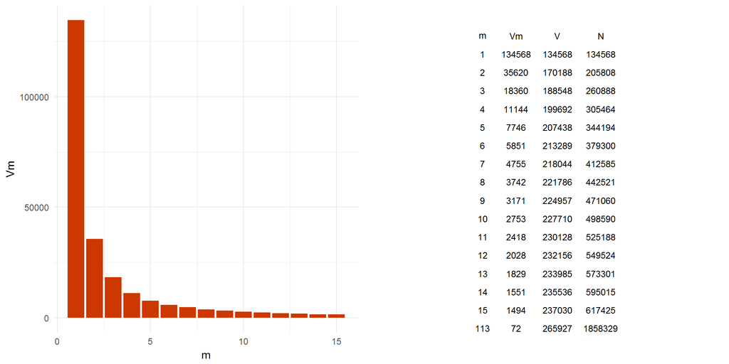

Figure 1: Frequency spectrum for blogs register

#### Applying Zipf’s Law to Lexical Size Problem

The next step in the analysis was to ascertain the degree to which Zipfs law, in its classic form, could be applied as above to determine optimal lexical size.

#### Zipfian Distribution Goodness-of-Fit

The Zipf Plot, which relates log rank to log frequency, provides a good visual indicator of goodness-of-fit. The data conform to Zipf’s law to the extent that the plot is linear. The following plots graphically characterize goodness-of-fit for each register.

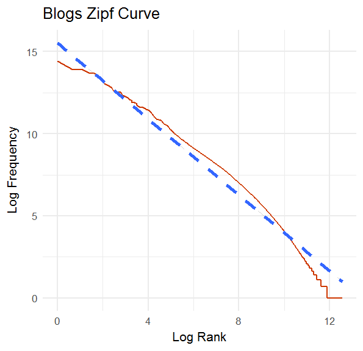

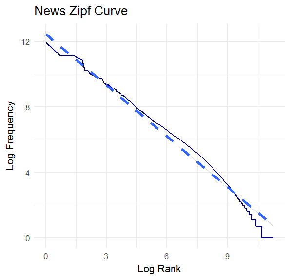

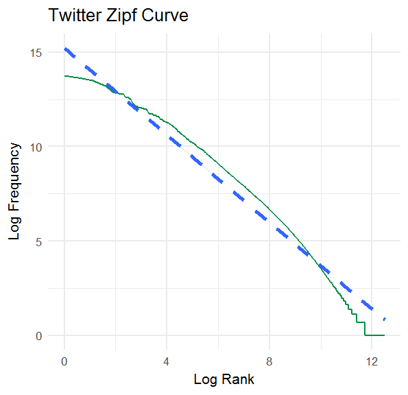

Figure 2: Zipfian Distribution Goodness of Fit

The curvilinear line shapes indicate systematic variation from a Zipfian distribution. The following residual plots confirm problems with goodness-of-fit.

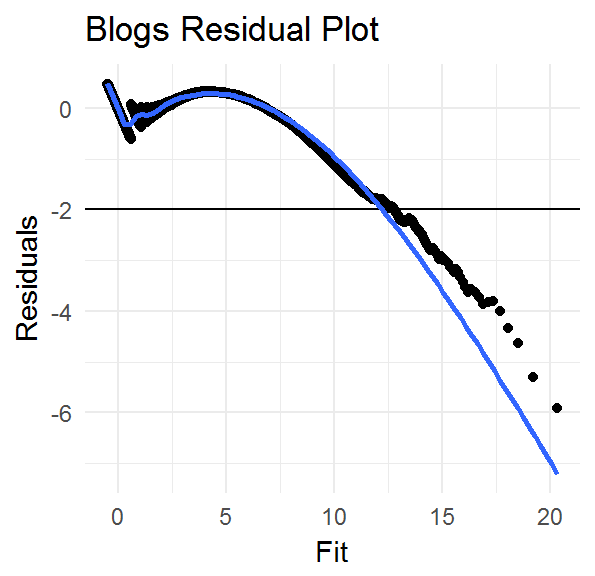

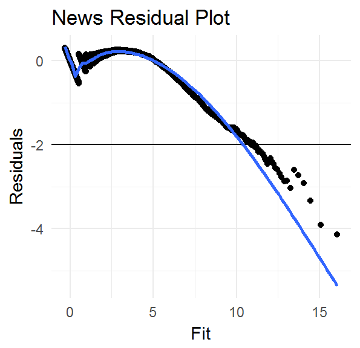

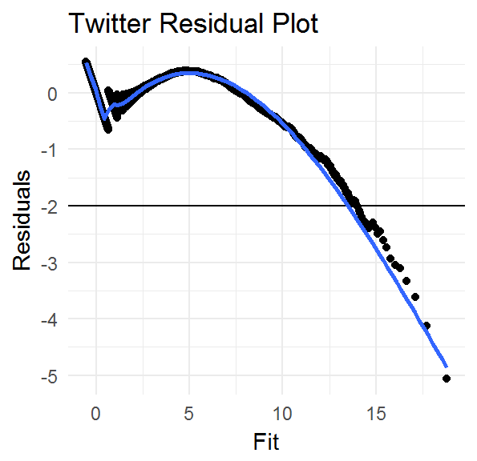

Figure 3: Zipf Residual Plots

This result was not surprising. In a large scale analysis of over 30,000 texts in the Project Gutenberg database (Moreno-Sanchez, Font-Clos, and Corral 2016), goodness of fit tests showed that only 15% of the texts were compatible with this form of Zipf’s law. The reason is that the language is creative, evolving, and characterized by a very large, perhaps infinite number of type probabilities and word frequency distributions are characterized by a large number of low probability events (Khmaladze 1988). Such distributions, referred to as LNRE (large number of rare event) distributions, contain rare events that occur in the population that do not occur in the sample, regardless of its size. Since the joint probability of unseen events in the sample sum up to 1, it must be adjusted to in order to free probability space for the unseen types (Baayen and R. H. Baayen 2008). Fortunately, LNRE models have been developed to adjust for the large probability of unseen events.

#### Zipf-Mandelbrot Model

One such LNRE model is based upon the following generalization of Zipf’s law proposed by Benoit Mandelbrot (Mandelbrot 1961).

$$f(r) = \frac{1}{(r+\beta)^\alpha}$$
By “shifting” the rank by an amount β, the Zipf-Mandelbrot (ZM) formulation more closely fits the frequency distribution in language [Zipf (1936); Zipf49; Mandelbrot1953; Mandelbrot61]. Using the zipfR package (Evert 2015), ZM models were independently fit against each register of the corpus. Parameters $\alpha$ and $\beta$ were estimated as follows:

Table 4: Zipf-Mandelbrot Model Parameters by Register

| Register | Alpha | Beta |
| --- | --- | --- |
| Blogs Register | 0.4839 | 0.0011 |
| News Register | 0.5020 | 0.0014 |
| Twitter Register | 0.5257 | 0.0021 |

**Frequency Spectra** Frequency spectra are the essential data structures used to estimate the required lexical vocabulary size to meet a language coverage target. Expected frequency spectra were estimated using the ZM model and are juxtaposed against the observed word frequency distributions from the corpus.

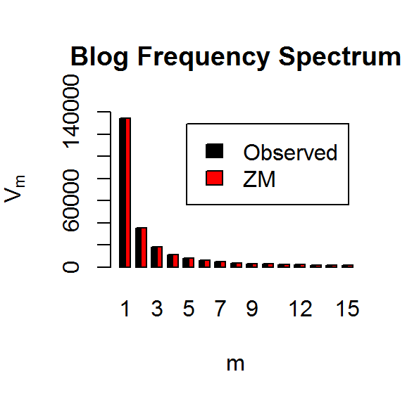

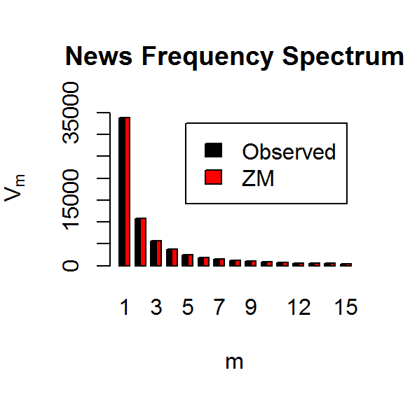

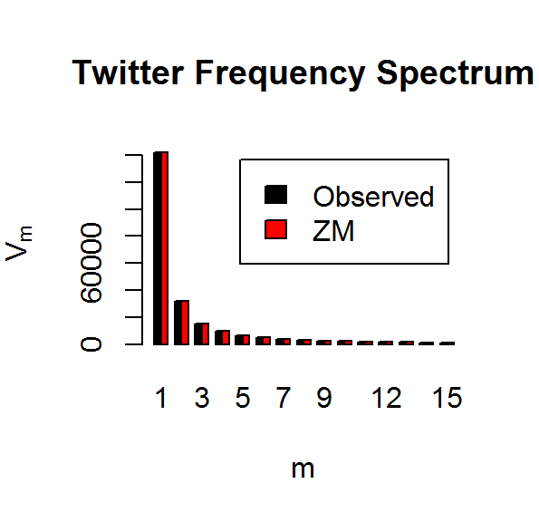

Figure 4: Zipf-Mandelbrot Expected vs. Observed Frequency Spectra

The observed and expected frequency spectra appear to fit very well. Next, the observed (smoothed) and extrapolated vocabulary growth curves are evaluated for fit.

**Vocabulary Growth Curves** Vocabulary growth curves (VGCs) relate vocabulary size $V$ to sample size $N$. Expected VGCs were extrapolated using the ZM model from observed VGCs and are plotted vis-a-vis smoother (interpolated) observed VGCs.

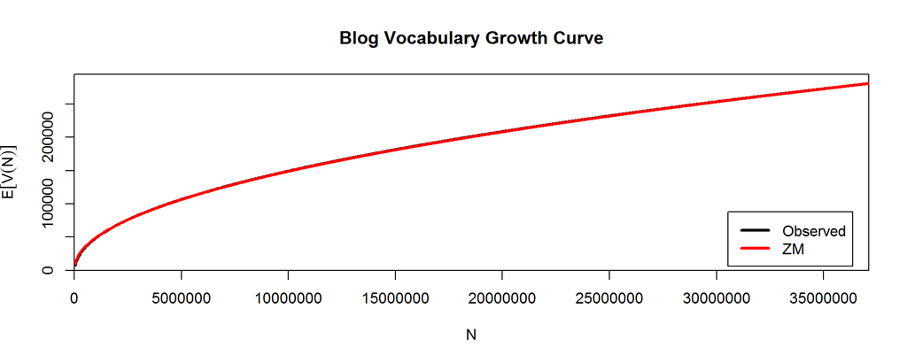

Figure 5: Zipf-Mandelbrot Expected vs. Observed Vocabulary Growth Curves (Blogs)

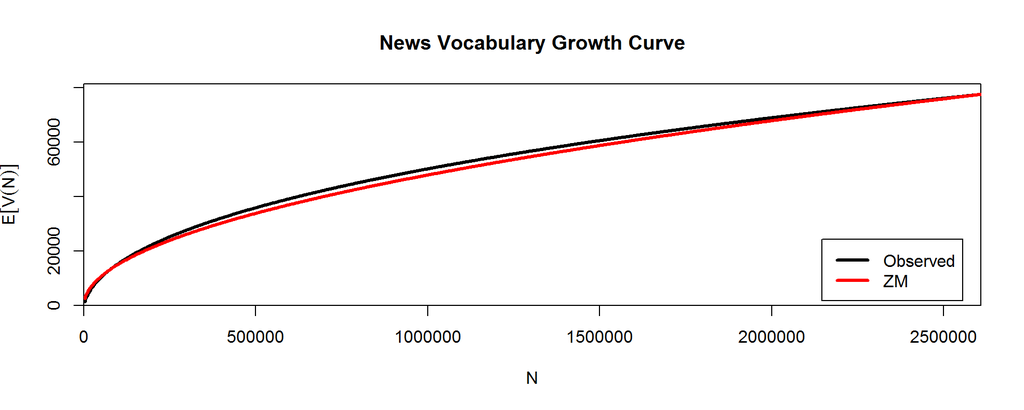

Figure 6: Zipf-Mandelbrot Expected vs. Observed Vocabulary Growth Curves (News)

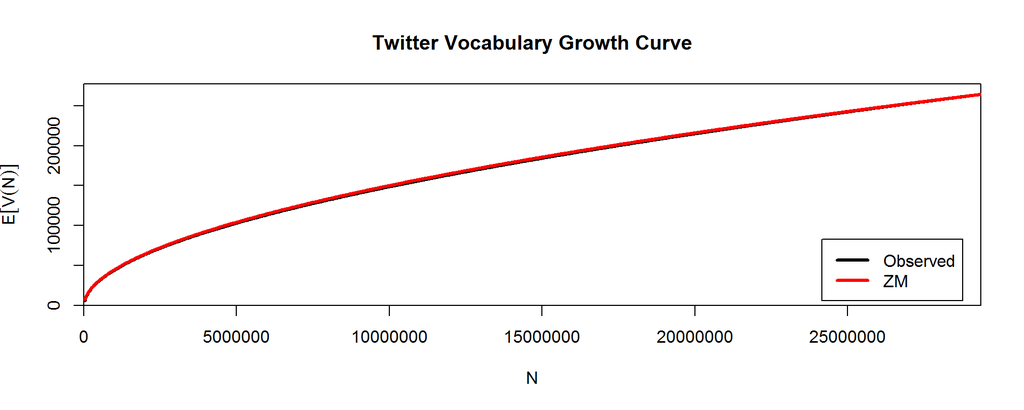

Figure 7: Zipf-Mandelbrot Expected vs. Observed Vocabulary Growth Curves (Twitter)

Both spectra and vocabulary growth curves fit the data reasonably well. Now, the lexical size can be estimated.

#### Lexical Size Estimate

The lexical size estimates were obtained by comparing observed vocabulary sizes $V$ of corpus registers at various sample sizes, with the ZM model derived expected vocabulary $EV$ of the HC Corpus registers. Using the ZipfR package (Evert 2015), frequency spectra were created for each register at varying sample sizes. Based upon these observed spectra, ZM models were trained and an expected vocabulary $EV$ size for the full corpus register was estimated. Out-of-vocabulary word types $Voov$ were calculated by subtracting the observed vocabulary $V$ from the ZM model expected vocabulary $EV$. Utilizing the ZM model derived frequency spectrum, the associated numbers of out-of-vocabulary tokens $Noov$ were determined by cumulatively summing the product of the frequency classes $m$ and the vocabulary $Vm$, until $Voov$ was reached. The out-of-vocabulary rate (OOV Rate) was obtained by dividing $Noov$ by the number of tokens in the HC Corpus register. The coverage rates at various sample sizes are summarized below.

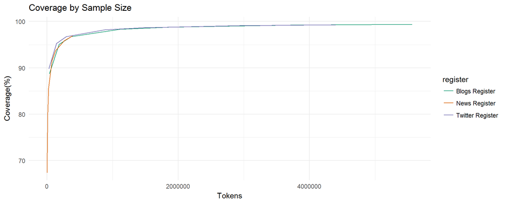

Figure 8: Lexical coverage by sample size

Table 5: Lexical diversity-based sample size estimate

| Register | % | Tokens | Sample V | Extrapolated V | Estimated Voov | Estimated Noov | OOV Rate | Coverage |
| --- | --- | --- | --- | --- | --- | --- | --- | --- |
| Blogs Register | 3 | 1,113,314 | 50,963 | 365,182 | 314,219 | 627,494 | 2 | 98 |
| News Register | 15 | 391,309 | 31,765 | 97,569 | 65,804 | 81,288 | 3 | 97 |
| Twitter Register | 3 | 880,644 | 41,194 | 309,381 | 268,187 | 527,587 | 2 | 98 |
| Corpus | 7 | 2,385,267 | 123,922 | 772,132 | 648,210 | 1,236,369 | 2 | 98 |

Next, the distribution of lexical features will be examined vis-a-vis the sample size estimation problem.

### Lexical Feature Analysis

Corpus representativeness, (Biber 1993) argues, also depends upon “the extent to which it contains the range of linguistic distributions in the population”. Thusly,this analysis examines the distribution of lexical features vis-a-vis optimal lexical size in terms of the size of the sampling unit, the number of sampling units in the overall lexical resource as well as the stratified representation of each register within the corpus. To capture the corpus’ linguistic nuances, the following 10 lexical features commonly used in variation studies were studied:

Table 6: Descriptive Statistics for frequency scores (per 2,000 words)

| Tag | Description | Mean | Max | Mean | Range | Total | % Total | SD | Variation Coefficient | Tolerable Error | Sample Size |
| --- | --- | --- | --- | --- | --- | --- | --- | --- | --- | --- | --- |
| IN | Preposition/Subord. Conj. | 204 | 294 | 247.24 | 90 | 24,724 | 19.99 | 20.33 | 0.08 | 12.36 | 10.39 |
| NN | Noun, Singular Or Mass | 351 | 514 | 418.86 | 163 | 41,886 | 33.86 | 33.96 | 0.08 | 20.94 | 10.10 |
| NNS | Noun Plural | 74 | 163 | 108.00 | 89 | 10,800 | 8.73 | 16.65 | 0.15 | 5.40 | 36.52 |
| PRP | Personal Pronoun | 63 | 169 | 122.06 | 106 | 12,206 | 9.87 | 23.57 | 0.19 | 6.10 | 57.32 |
| VB | Verb Be, Base Form | 61 | 155 | 103.06 | 94 | 10,306 | 8.33 | 22.87 | 0.22 | 5.15 | 75.70 |
| VBD | Verb Be, Past | 35 | 111 | 66.63 | 76 | 6,663 | 5.39 | 17.52 | 0.26 | 3.33 | 106.21 |
| VBG | Verb Be, Gerund/Participle | 30 | 71 | 50.15 | 41 | 5,015 | 4.05 | 9.53 | 0.19 | 2.51 | 55.51 |
| VBN | Verb Be, Past Participle | 22 | 71 | 43.92 | 49 | 4,392 | 3.55 | 11.39 | 0.26 | 2.20 | 103.43 |
| VBZ | Verb Be, Pres, 3Rd P. Sing | 40 | 86 | 65.28 | 46 | 6,528 | 5.28 | 10.18 | 0.16 | 3.26 | 37.36 |
| WP | Wh-Pronoun | 4 | 22 | 11.85 | 18 | 1,185 | 0.96 | 3.98 | 0.34 | 0.59 | 173.40 |

#### Sampling Unit

Table 7: Chi-Square p-values for distribution of lexical features between texts

| Register | Size | IN | NN | NNS | PRP | VB | VBD | VBG | VBN | VBZ | WP | Mean |
| --- | --- | --- | --- | --- | --- | --- | --- | --- | --- | --- | --- | --- |
| Blogs Register | 2,000 | 0.7647 | 0.0062 | 0.5483 | 0.0001 | 0.0477 | 0.0000 | 0.2185 | 0.0989 | 0.0009 | 0.3402 | 0.2026 |
| News Register | 2,000 | 0.7146 | 0.0543 | 0.6360 | 0.0075 | 0.3475 | 0.0049 | 0.0374 | 0.0977 | 0.5987 | 0.6913 | 0.3190 |
| Twitter Register | 2,000 | 0.4754 | 0.4313 | 0.8089 | 0.1013 | 0.4746 | 0.5568 | 0.8177 | 0.3353 | 0.6187 | 0.5769 | 0.5197 |
| Corpus Mean | 2,000 | 0.6515 | 0.1639 | 0.6644 | 0.0363 | 0.2899 | 0.1872 | 0.3579 | 0.1773 | 0.4061 | 0.5361 | 0.3471 |

#### Total Corpus Size

Total corpus size is based upon the distribution characteristics of each linguistic feature. More precisely, there are $n_i$ different estimates of total corpus size, one for each of the $i$ lexical features. Once a calculation is made for each feature $i$, the largest $n$ was selected as the estimate. The corpus size estimate is thereby given by the following equation:
$$max(n_i) = \frac{s^2}{(\frac{te}{t})^2}$$
where $n_i$ is the computed sample size, in terms of contiguous sampling units, associated with the $i$th lexical feature, $s$ is the estimated standard deviation of the feature in the population, $te$ is the tolerable error (equal to 1/2 of the desired 95% confidence interval), $t$ is the $t$-value for the desired probability level (1.79588482 for $\alpha$ = 0.05 with 11 degrees of freedom) (Biber 1993).

#### Register Size

The sample size for each register comprised a base component - a minimum number of texts to be allocated to each register - plus a proportional component that was based upon the degree of variation in each register. The formula for calculating register sample size is:
$$n_r = (t\cdot b) + \lambda \cdot avc_r$$
where $r$ is the register, $t$ is total corpus size, 173, and $b = 0.1$, the base allocation or the fraction of the total corpus that each register was allocated. Lambda is:
$$\lambda = \frac{t - \displaystyle\sum_{i=1}^{r} t \cdot b}{\displaystyle\sum_{i=1}^{r} avc_r}$$
The numerator is the proportional allocation, total corpus size minus the base for each register. The average variation coefficient $avc_r$ for each register is calculated as follows:
$$avc_r = \frac {1}{f} \cdot \displaystyle\sum_{i=1}^{f} \frac{sd_f}{\mu_f}$$
where $f$ is 10, the number of features studied, $sd_f$ is the standard of deviation for feature $f$, and $\mu_f$ is the mean distribution for feature $f$. As such, the sample size allocated to each register is:

Table 9: Sample sizes for each register

| Register | Base | Avg VC | Lambda | Proportion | Num Samples | Sample Length | Sample Size |
| --- | --- | --- | --- | --- | --- | --- | --- |
| Blogs Register | 17 | 0.15 | 298 | 44 | 61 | 2,000 | 122,000 |
| News Register | 17 | 0.14 | 298 | 42 | 59 | 2,000 | 118,000 |
| Twitter Register | 17 | 0.12 | 298 | 37 | 54 | 2,000 | 108,000 |
| Corpus | 51 | 0.41 | 298 | 123 | 174 | 2,000 | 348,000 |

### Pilot Corpus Sampling Strategy

The following summarizes the sample size estimates using the lexical diversity and lexical feature analyses.

Table 10: Sample Size Estimate Analyses (Tokens)

| Register | HC Corpus | Diversity-Based Estimate | Lexical Feature-Based Estimate | Tokens | Sentences | % Total | Proportion |
| --- | --- | --- | --- | --- | --- | --- | --- |
| Blogs Register | 37,110,484 | 1,113,314 | 122,000 | 1,113,314 | 69,464 | 3 | 47 |
| News Register | 2,608,731 | 391,309 | 118,000 | 391,309 | 22,517 | 15 | 16 |
| Twitter Register | 29,354,830 | 880,644 | 108,000 | 880,644 | 111,069 | 3 | 37 |
| Corpus | 69,074,045 | 2,385,267 | 348,000 | 2,385,267 | 203,050 | 3 | 100 |

Several observations are worth noting. First, the lexical diversity-based estimate of 2,385,267 tokens was significantly greater than that of the lexical feature analysis. The second notable observation was the vast difference in the proportional representation of the news register vis-a-vis that of the blog and twitter registers. Given the lexical diversity of the news register, 15% of the news register was required to represent linguistic characteristics of the population of news content in the HC Corpus, versus 3% for the blog and twitter registers. Despite this, the news register accounted for just 16% of the pilot corpus. The blogs and twitter registers accounted for Some 84% of the pilot. The last, and somewhat surprising observation was that lexical diversity and density representation could be achieved with just 3% of the HC Corpus.

Taking a conservative approach, the total and per-register pilot corpus sample sizes would come from the lexical diversity analysis. The sampling unit derived from the lexical feature analysis would be converted to sentences based upon average sentence length of each register. Lastly, to work with round numbers, the pilot corpus sample size was extrapolated out to 5%, while maintaining the proportional representation of each register. The following table outlines the extrapolated pilot corpus sample size assuming a 2,000 token sampling unit as given by the lexical feature analysis.

Table 11: Pilot corpus design

| Register | HC Corpus (Tokens) | % Total | Tokens | Sentences | Chunk Size (Tokens) | Sentences per Chunk | # Chunks | Sample Size (Sentences) |
| --- | --- | --- | --- | --- | --- | --- | --- | --- |
| Blogs Register | 37,110,484 | 5 | 1,855,524 | 115,774 | 2,000 | 124 | 933 | 115,692 |
| News Register | 2,608,731 | 25 | 652,183 | 37,529 | 2,000 | 115 | 326 | 37,490 |
| Twitter Register | 29,354,830 | 5 | 1,467,742 | 185,116 | 2,000 | 252 | 734 | 184,968 |
| Corpus | 69,074,045 | 5 | 3,453,702 | 308,396 | 2,000 | 178 | 1,732 | 308,296 |

### Pilot Corpus Verification

In order to test whether the pilot corpus was truly representative, two tests were conducted. The first checked the number of OOV words in the pilot corpus. More concretely, the number of words in the cleaned HC Corpus that were not in the pilot corpus was normalized by the HC Corpus vocabulary size to obtain an OOV Rate. Next, a comparison of the distribution of lexical features between the corpora was tested for similarity using a chi-squared test.

#### Vocabulary Verification

The following table summarizes the vocabulary and token OOV rates for the pilot corpus.

Table 12: Pilot corpus vocabulary OOV Rates

| Registers | HC Corpus Vocabulary | HC Corpus Tokens | Pilot Corpus Vocabulary | Pilot Corpus Tokens | # OOV Words | OOV Rate | Coverage |
| --- | --- | --- | --- | --- | --- | --- | --- |
| Blogs Register | 280,731 | 37,110,484 | 62,513 | 1,851,271 | 661,232 | 2 | 98 |
| News Register | 77,534 | 2,608,731 | 37,705 | 643,210 | 69,627 | 3 | 97 |
| Twitter Register | 264,089 | 29,354,830 | 53,008 | 1,468,880 | 552,364 | 2 | 98 |
| Corpus | 622,354 | 69,074,045 | 153,226 | 3,963,361 | 1,283,223 | 2 | 98 |

#### Lexical Feature Verification

Chi-squared tests were conducted on the distributions of POS tags in the HC and pilot corpus. The hypothesis was that no statistically significant differences existed between the distributions of lexical features in the HC and pilot corpora. This hypothesis was rejected if data showed a difference with a five percent or less probability.

Table 13: Lexical Feature Distribution HC Corpora vis-a-vis Pilot Corpus (p-Value = 0.2313417)

| Tag | Description | HC Corpus | Training Corpus |
| --- | --- | --- | --- |
| IN | Preposition/Subord. Conj. | 242.79 | 243.61 |
| NN | Noun, Singular Or Mass | 406.67 | 419.89 |
| NNS | Noun Plural | 111.50 | 113.35 |
| VB | Verb Be, Base Form | 128.47 | 118.89 |
| VBD | Verb Be, Past | 107.99 | 102.75 |
| VBG | Verb Be, Gerund/Participle | 64.40 | 69.12 |
| VBN | Verb Be, Past Participle | 51.03 | 49.43 |
| VBZ | Verb Be, Pres, 3Rd P. Sing | 43.67 | 44.32 |
| PRP | Personal Pronoun | 63.03 | 62.64 |
| WP | Wh-Pronoun | 12.11 | 12.21 |

The high p-Value indicated that there was a 23.1 percent chance that the differences were due to chance. Therefore, the hypothesis is not rejected and the Pilot Corpus represents the range of lexical variation of the HC Corpus.

Having established a representative pilot corpus, the training, validation, and test sets were designated as described in the next section.

## Data Splitting

The model corpora, consisting of four training sets, a validation set and a test set would be comprised of one or more pilot corpora. One pilot corpus was set aside for the validation set and another for the test set. The remaining data was split among four training sets: alpha, beta, gamma, and delta, which constituted approximately 10%, 20%, 35%, and 50% of the overall corpus size respectively. The design is summarized below.

Table 14: Model Corpora Design

| Registers | Alpha | Beta | Gamma | Delta | Validation | Test |
| --- | --- | --- | --- | --- | --- | --- |
| Blogs | 231,384 | 578,460 | 1,156,920 | 1,619,688 | 115,692 | 115,692 |
| News | 74,980 | 74,980 | 74,980 | 74,980 | 37,490 | 37,490 |
| Twitter | 369,936 | 924,840 | 1,849,680 | 2,589,552 | 184,968 | 184,968 |
| Corpus | 676,300 | 1,578,280 | 3,081,580 | 4,284,220 | 338,150 | 338,150 |

## Data Exploration

The qualitative and quantitative exploratory data analysis (EDA) summarized in this section was conducted on a pilot corpus as well as the four training sets. An examination of the pilot corpus provided a sense of the lexical and linguistic features, their distributions, n-grams and frequencies. The training set evaluation focused on lexical coverage of the various training sets vis-a-vis the validation set.

### Pilot Corpus EDA

#### Descriptive Statistics

The following table outlines the descriptive statistics for the training corpus.

Table 15: Pilot Corpus Descriptive Statistics

| Genre | Size (MB) | Sentences | Tokens | Words | Types | Mean Sentence Length | Mean Word Length |
| --- | --- | --- | --- | --- | --- | --- | --- |
| Blogs Register | 18 | 115,692 | 1,851,271 | 1,851,271 | 61,625 | 16 | 4 |
| News Register | 7 | 37,490 | 643,210 | 643,210 | 37,087 | 17 | 5 |
| Twitter Register | 14 | 184,968 | 1,468,880 | 1,468,880 | 52,124 | 8 | 4 |
| Corpus | 40 | 338,150 | 3,963,361 | 3,963,361 | 95,052 | 12 | 4 |

Reducing the size of the corpus by 94% while retaining the lexical diversity and feature distribution of the HC Corpus, was the **key finding** of this analysis.

#### Lexical Diversity Analysis

Lexical diversity, or richness, is a measure of the different words that are used in a text. Various measures of lexical richness: Yule’s K (Yule 1944), the Zipf slope (Zipf 1935), the type-token ratio, Herdan’s C (Herdan 1960), Guiraud’s R (Guiraud 1954), the mean log frequency (Carroll 1967), the Mean Segmental Type-Token Ratio (Johnson 1944) and the vocabulary growth rate (the ratio of hapax legomena to tokens sampled) (Baayen and R. H. Baayen 2008) were calculated and plotted cumulatively over samples from each register. Since the lexical diversity measures above are sensitive to sample size, the lexical diversity measures were computed on single samples of 643,200 tokens taken from each register.

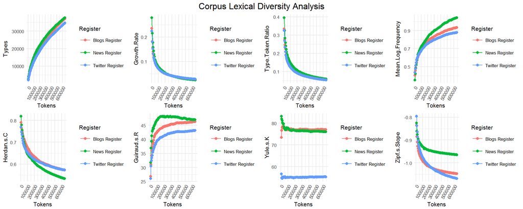

Figure 10: Pilot Corpus Lexical Diversity Analysis

The curvilinear distribution of word types (upper left), shows that vocabulary growth is relatively stable within text segments, but the occurrences of new types decrease throughout the course of the text. The vocabulary growth rate is the probability of encountering an unseen type, after having read $N$ tokens, and is estimated by the ratio of the number of hapax legomena (types of frequency 1), to the number of tokens, $N$. The type token ratio decreased rapidly as the number of tokens read approached approximately 100,000 tokens, then decreased at a slower rate as the number of tokens read increased. The mean log frequency is the average frequency of all words that appear up to $N$ tokens read. Herdan’s C is the ratio of the log of the vocabulary size $V$ and tokens $N$ (Herdan 1960). Guiraud’s R is the ratio of the vocabulary $V$ and the square root of the number of tokens $N$. Yule’s K, often used for author attribution of literary texts, is a measure of lexical repetition that is independent of text size. Finally, Zipf’s Slope (Baayen 2013) is Zipf’s rank-frequency curve in the double-logarithmic space.

Table 16: Lexical Diversity Measures at $N$ = 643,200 tokens

| Category | TypeTokenRatio | Lognormal | Herdan | Guiraud | Yule | Zipf |
| --- | --- | --- | --- | --- | --- | --- |
| Blogs | 0.06 | 0.93 | 0.57 | 46.28 | 77.08 | -1.05 |
| News | 0.06 | 1.04 | 0.53 | 47.01 | 76.03 | -0.96 |
| Twitter | 0.05 | 0.88 | 0.57 | 43.19 | 55.29 | -1.07 |

Table 16 summarizes the relative lexical diversity measures for 643,200 tokens read from each register.

#### Lexical Density Analysis

Lexical density, the ratio of content words (nouns, adjectives, verbs, adverbs) to all words in a text, is an estimated measure of content within a text. While N-Gram models work well with function words, they tend to underperform in content word prediction. Incorporating semantic information contained in content words can improve overall prediction accuracy. Lexical density measures can indicate the degree to which semantic analysis can improve overall prediction accuracy.

Table 17: Lexical Density Analysis of Pilot Corpus

| Register | Tokens | Content Words | Density |
| --- | --- | --- | --- |
| Blogs Register | 1,919,665 | 739,791 | 38.5 |
| News Register | 664,324 | 292,121 | 44.0 |
| Twitter Register | 1,547,374 | 630,444 | 40.7 |
| Corpus | 4,131,363 | 1,662,356 | 40.2 |

Overall density for the corpus was 40%, with the news register leading the group at 44%. The blogs register, somewhat surprisingly, had the lowest percentage of content words. The **key finding**, in any case, was the seemingly low level of lexical density in the corpus. The potential impact of semantic analysis on prediction accuracy remained an open question at this stage of the analysis.

#### Lexical Feature Analysis

The following plot depicts the distribution of select lexical features commonly used in variation studies.

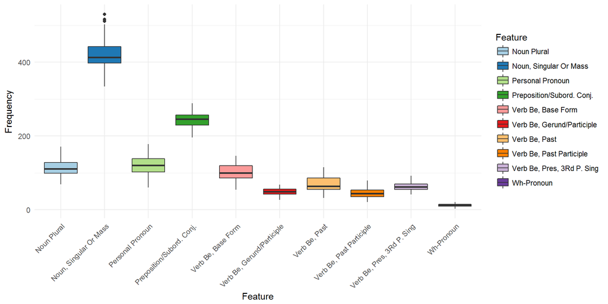

Figure 11: Lexical Feature Distributions (per 2,000 words)

#### Word N-Gram Frequency Distribution Analysis

Here, the frequency distribution of word N-Grams was evaluated vis-a-vis a zipfian distribution. This analysis intimates the validity of zipf-based inferences on downstream language modeling tasks, such as language model pruning. zipf plots reveal the extent to which the frequencies of nGrams modeled a zipfian distribution.

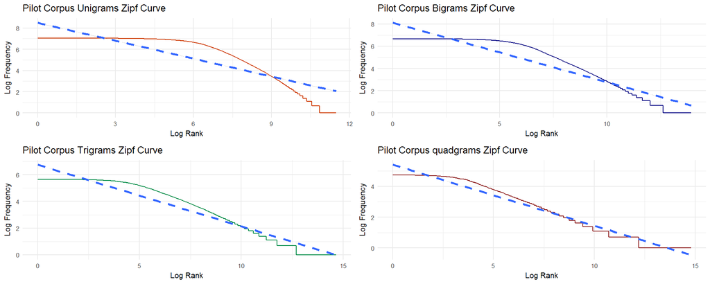

Figure 12: N-Gram Zipf Plots

The **key finding**, as shown in Figure 12, was that the visual indication of goodness-of-fit revealed systematic deviations from a zipfian distribution. Any downstream word frequency based decisions would require a LNRE model such as the Zipf-Mandelbrot (Mandelbrot 1961) model used during the corpus design phase.

#### Word N-Gram Coverage Analysis

This section examines the numbers of total n-grams covered as new n-grams are introduced. Again, this analysis would inform any language model pruning required downstream.

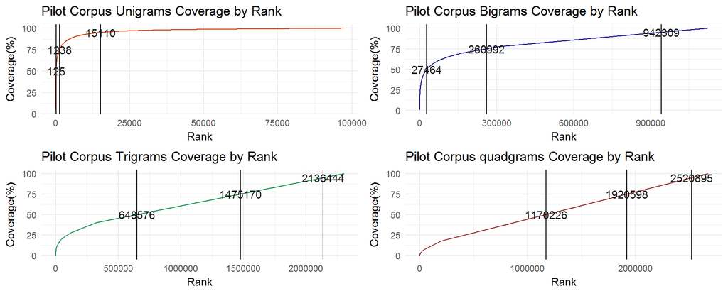

Figure 13: Word N-Gram Coverage

Each plot is annotated with the number of N-Grams required to achieve 50%, 75%, and 95% coverage of all N-Grams in the Pilot Corpus. Despite the deviations from the zipf distribution, the unigram coverage data behaved in a rather “zipfian” manner. On the other hand, the coverage curves for the bigrams, trigrams, and quadgrams didn’t reflect a “zipfian” behavior in the least. The trigram and quadgram coverage plots are nearly linear. The **key finding** of this analysis was that any pruning from the higher-order n-grams would have a significant and detrimental affect on coverage, and prediction accuracy.

#### Word N-Gram Feature Analysis

The pilot corpus comprised some 97,231 unigrams, 1,122,676 bigrams, 2,299,204 trigrams, and 2,667,930 quadgrams. The following illuminates the top 50 features by frequency for each N-Gram order.

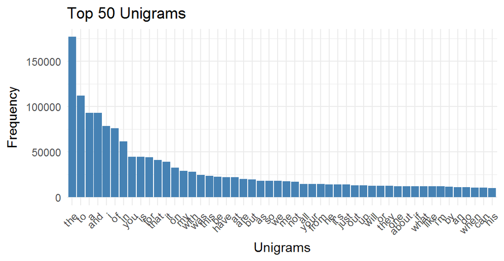

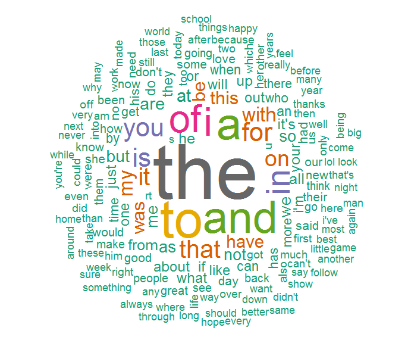

Figure 14: 50 Most frequent of $N$ = 97,231 unigrams

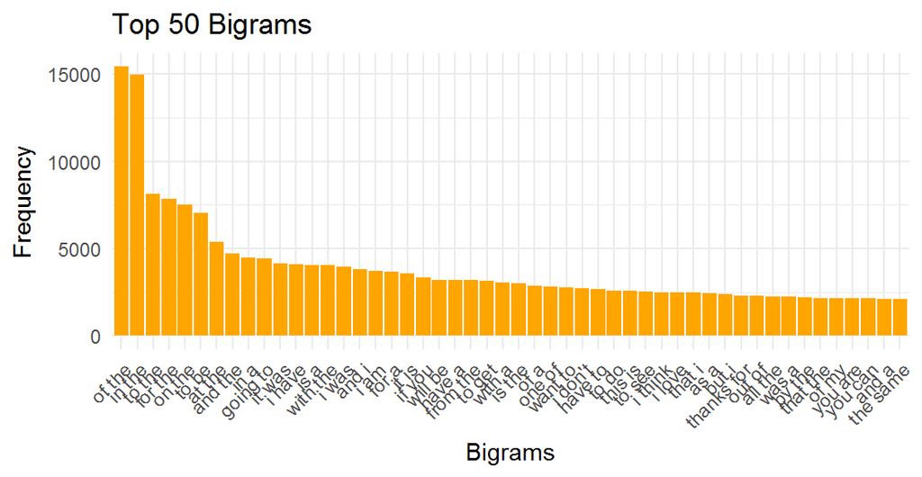

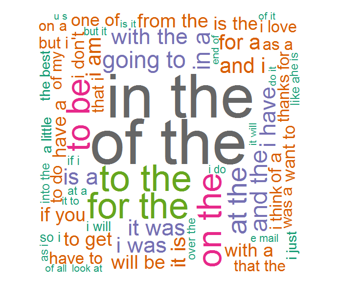

Figure 15: 50 Most frequent of $N$ = 1,122,676 bigrams

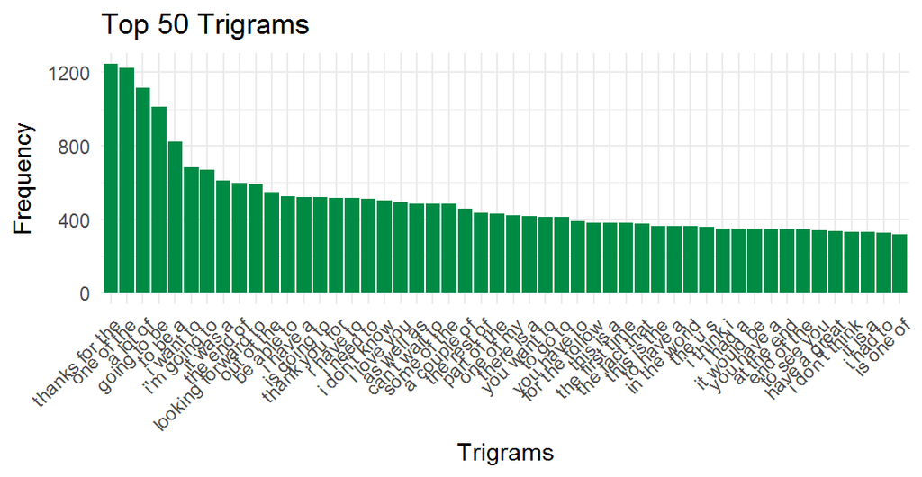

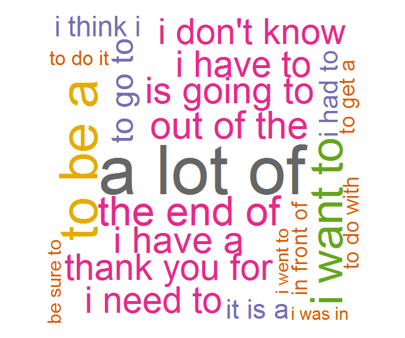

Figure 16: 50 Most frequent of $N$ = 2,299,204 trigrams

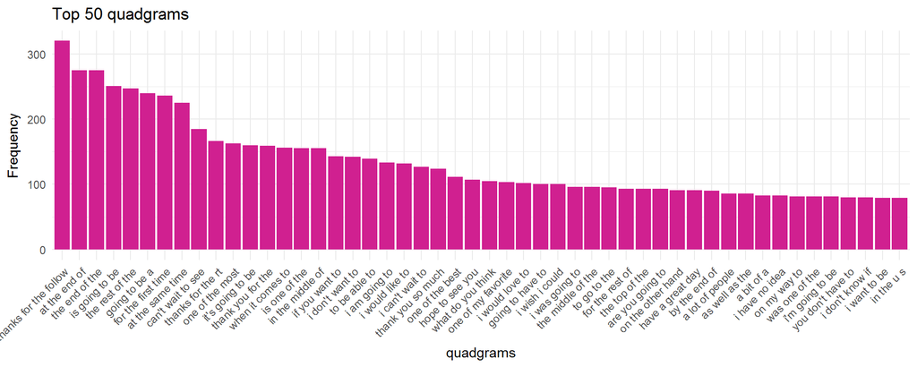

Figure 17: 50 Most frequent of $N$ = 2,667,930 quadgrams

This analysis reveals the degree to which lexical density increases with each higher-order ngram. The most frequent unigrams were comprised almost exclusively of function words. The proportion of content words in the top n-gram features increases with each higher-order. The **key finding** of this analysis was that content increases with context.

Next, the lexical coverage of each training set is evaluated vis-a-vis the validation test sets.

### Training Sets EDA

The primary inquiry for the training sets was the degree to which the training sets covered the validation and test set nGrams. The following tables summarize the unigram, bigram, trigram, and quadgram coverages for training sets alpha thru delta.

Table 18: nGram Coverage for Training Set Alpha

| Training Set | nGram | Training nGram Types | Training nGrams | Validation Set nGrams | Validation OOV | Validation OOV Rate | Validation Coverage | Test Set nGrams | Test OOV | Test OOV Rate | Test Coverage |
| --- | --- | --- | --- | --- | --- | --- | --- | --- | --- | --- | --- |
| Training Set Alpha | Unigrams | 142,239 | 7,937,143 | 3,972,730 | 39,218 | 0.01 | 99.01 | 3,972,610 | 39,191 | 0.01 | 99.01 |
| Training Set Alpha | Bigrams | 1,962,136 | 7,260,915 | 3,634,580 | 738,864 | 0.20 | 79.67 | 3,634,551 | 739,817 | 0.20 | 79.64 |
| Training Set Alpha | Trigrams | 4,421,440 | 6,614,360 | 3,311,154 | 1,953,390 | 0.59 | 41.01 | 3,311,241 | 1,956,374 | 0.59 | 40.92 |
| Training Set Alpha | Quadgrams | 5,404,883 | 6,006,311 | 3,006,981 | 2,587,171 | 0.86 | 13.96 | 3,007,372 | 2,588,937 | 0.86 | 13.91 |

Table 19: nGram Coverage for Training Set Beta

| Training Set | nGram | Training nGram Types | Training nGrams | Validation Set nGrams | Validation OOV | Validation OOV Rate | Validation Coverage | Test Set nGrams | Test OOV | Test OOV Rate | Test Coverage |
| --- | --- | --- | --- | --- | --- | --- | --- | --- | --- | --- | --- |
| Training Set Beta | Unigrams | 216,229 | 17,905,498 | 3,972,730 | 27,522 | 0.01 | 99.31 | 3,972,610 | 27,439 | 0.01 | 99.31 |
| Training Set Beta | Bigrams | 3,502,320 | 16,327,347 | 3,634,580 | 590,576 | 0.16 | 83.75 | 3,634,551 | 592,510 | 0.16 | 83.70 |
| Training Set Beta | Trigrams | 8,820,319 | 14,821,898 | 3,311,154 | 1,733,109 | 0.52 | 47.66 | 3,311,241 | 1,735,929 | 0.52 | 47.57 |
| Training Set Beta | Quadgrams | 11,509,958 | 13,409,774 | 3,006,981 | 2,452,979 | 0.82 | 18.42 | 3,007,372 | 2,454,946 | 0.82 | 18.37 |

Table 20: nGram Coverage for Training Set Gamma

| Training Set | nGram | Training nGram Types | Training nGrams | Validation Set nGrams | Validation OOV | Validation OOV Rate | Validation Coverage | Test Set nGrams | Test OOV | Test OOV Rate | Test Coverage |
| --- | --- | --- | --- | --- | --- | --- | --- | --- | --- | --- | --- |
| Training Set Gamma | Unigrams | 305,595 | 34,507,750 | 3,972,730 | 20,843 | 0.01 | 99.48 | 3,972,610 | 20,797 | 0.01 | 99.48 |
| Training Set Gamma | Bigrams | 5,565,138 | 31,426,299 | 3,634,580 | 488,296 | 0.13 | 86.57 | 3,634,551 | 490,617 | 0.13 | 86.50 |
| Training Set Gamma | Trigrams | 15,316,828 | 28,488,237 | 3,311,154 | 1,559,980 | 0.47 | 52.89 | 3,311,241 | 1,564,088 | 0.47 | 52.76 |
| Training Set Gamma | Quadgrams | 21,114,676 | 25,735,127 | 3,006,981 | 2,332,793 | 0.78 | 22.42 | 3,007,372 | 2,336,134 | 0.78 | 22.32 |

Table 21: nGram Coverage for Training Set Delta

| Training Set | nGram | Training nGram Types | Training nGrams | Validation Set nGrams | Validation OOV | Validation OOV Rate | Validation Coverage | Test Set nGrams | Test OOV | Test OOV Rate | Test Coverage |
| --- | --- | --- | --- | --- | --- | --- | --- | --- | --- | --- | --- |
| Training Set Delta | Unigrams | 363,464 | 47,793,875 | 3,972,730 | 18,158 | 0.00 | 99.54 | 3,972,610 | 18,052 | 0.00 | 99.55 |
| Training Set Delta | Bigrams | 6,994,556 | 43,509,784 | 3,634,580 | 442,468 | 0.12 | 87.83 | 3,634,551 | 445,032 | 0.12 | 87.76 |
| Training Set Delta | Trigrams | 20,111,966 | 39,425,805 | 3,311,154 | 1,475,818 | 0.45 | 55.43 | 3,311,241 | 1,479,588 | 0.45 | 55.32 |
| Training Set Delta | Quadgrams | 28,500,424 | 35,599,861 | 3,006,981 | 2,269,406 | 0.75 | 24.53 | 3,007,372 | 2,272,918 | 0.76 | 24.42 |

### Exploratory Data Analysis (EDA) Summary

Eight analyses were undertaken to reveal linguistic characteristics of the pilot and training set corpora that could be exploited during the language modeling phase. The following summarizes the key findings from each analysis.

1. **Pilot Corpus Descriptive Statistics** - outlined the basics in terms of numbers of sentences, words and word types for the pilot corpus.
2. **Pilot Corpus Lexical Diversity Analysis** - confirmed that the greater the lexical diversity of a register, the greater the sampling proportion required to be representative.
3. **Pilot Corpus Lexical Density Analysis** - the seemingly low lexical density estimates called into question the value of an integrated semantic prediction model.
4. **Pilot Corpus Lexical Feature Analysis** - the range and distribution of lexical features across registers, was a positive indication for an integrated word and POS-based N-Gram prediction model.
5. **Pilot Corpus Word N-Gram Frequency Distribution Analysis** - the distribution of n-grams did not model a “zipfian” distribution.
6. **Pilot Corpus Word N-Gram Coverage Analysis** - any pruning from the higher-order n-grams would have a significant and detrimental affect on coverage, and prediction accuracy.
7. **Pilot Corpus Word N-Gram Feature Analysis** - the increased lexical density of higher-order n-grams showed that content increases with context
8. **Training Set nGram Coverage Analysis** - validation and test set nGram coverage increases significantly with training set size

### Corpus Processing

Three corpus processing steps preceded the language modeling phase: OOV processing, sentence annotation, and n-gram creation.

**OOV Processing** To avoid zero probabilities during intrinsic evaluation of the language models, all training set hapax legomena (words occurring once) were replaced with “UNK”, a pseudo word indicating the presence of an unknown word. In addition, all words in the test and validation sets that did not occur in the training set were similarly replaced with “UNK”.

**Sentence Annotation** Separate texts, one for each n-gram order, were created from the training set and were annotated with beginning and end of sentence boundary tokens “BOS” and “EOS” respectively. Each word and POS sentence began with $n-1$ “BOS” tokens, where $n$ is the n-gram order. The end of each sentence was punctuated with a single “EOS” token. The word and POS-based models were 3 and 2 degree Markov models respectively.

The next section outlines the design, implementation and integration of the language models.

## Modeling

### Modified Kneser-Ney

The baseline model for this experiment was a Modified Kneser-Ney language model with three degrees of freedom, also known as a 4-gram model. The reader is encouraged to review Kneser-Ney and Modified Kneser-Ney smoothing algorithms from the introduction section. Rather than calculating discounts, continuation probabilities, and interpolation weights in real-time, those values are precalculated thereby reducing real-time word prediction to a search efficiency problem. The pipeline from initialization through intrinsic model evaluation was comprised of five key steps: model initialization, counting, calculation, compression and evaluation.

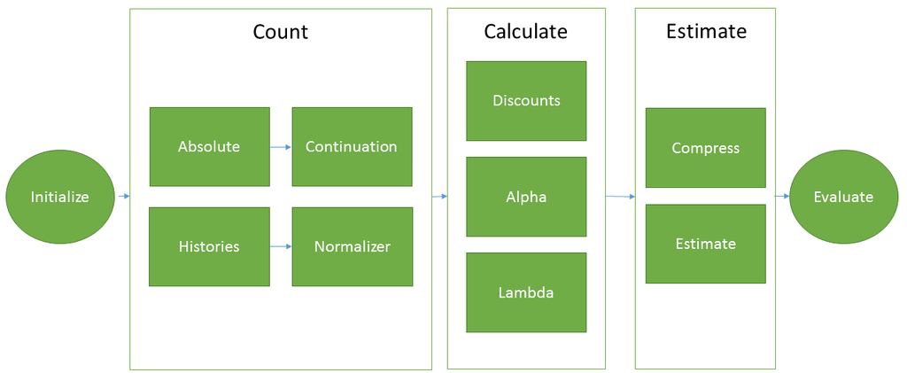

Figure 18: Modified Kneser-Ney Language Model Implementation Pipeline

**Initialize** The 4-Gram model was initialized by loading the n-grams into separate data tables according to n-gram order. N-Gram contexts $w_{1-n+1}^{i-1}$ and suffixes, $w_{1-n+2}^i$, were also parsed and stored. The n-grams include $n-1$ start-of-sentence tags per sentence and one end-of-sentence tag.

[figure not shown]

Absolute counts, typically denoted as $c(w_{i-n+1}^i)$ or $c(w_{i-n+1}^{i-1})$ are the absolute occurrences of n-grams, or their contexts found in the corpus. Continuation counts, designated by $N_{1+}(\bullet w_{i-n+1}^i)$, capture the number of times a word or sequence has been encountered as a novel continuation of a single-word context in the corpus. Continuation counts, which replace absolute counts used in maximum likelihood estimates, are the counts to which the discounts are applied in order to arrive at a continuation count. History counts, designated by ($N_{n}(w_{i-n+1}^{i-1} \bullet)$), are used to calculate the lambda, the weighting factor for lower order probability estimates. They capture the number of times an n-gram’s context occurs as context for other distinct single-words, precisely $n$ times. Lastly the normalizer counts convert continuation counts for n-grams of order $n<N$ to continuation probabilities. The normalizer for n-gram order of $n<N$ is the number of unique $n+1$-grams in the model. For n-grams of order $n=N$, the normalizer is the absolute count of the prefix in the model.

**Calculate** Three types of calculations are performed: discounts, alpha probabilities, and lambda weighting factors.  
Table 23: Modified Kneser-Ney Language Calculations

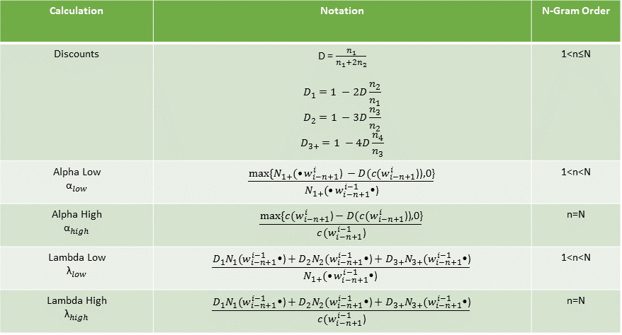

Discounts are calculated at each n-gram order and are a function of the number of times a particular word or sequence is encountered precisely $n=1$, $n=2$,$n=3$, or $n=4$ times in the model. There are two alpha probabilities, one for n-gram orders $1<n<N$ and one for the highest level $n=N$. In $\alpha_{low}$ the discount is applied to the n-gram’s continuation count, and is normalized by ${N_{1+}(\bullet w_{i-n+1}^{i-1}\bullet)}$, which is the number of unique n-grams that appear at least once at n-gram level $n+1$. At the highest level, $n=N$, $\alpha_{high}$ the discount is applied to the absolute count of the n-gram and is normalized by the absolute number of times the context appears in the corpus. Similarly, there are two lambda formulations: (1) $\lambda_{low}$ for n-gram orders $1<n<N$ and (2) $\lambda_{high}$ for the highest level $n=N$. The numerator in both counts, is the sum of the products of the discounts and the continuation counts. The denominator for the lower n-grams is the number of unique n-grams that appear at least once at n-gram level $n+1$. The higher order lambda formulation is normalized by the absolute count of the n-gram’s context in the corpus.

**Estimate** Before the estimation is performed, the language model is compressed by removing all the intermediate values that are not used in the final estimation. Subsequently, three types of estimates were performed: (1) $P_{MKN}(W_i)$, the unigram level estimate, (2) $P_{MKN}^{low}(w_i|w_{i-n+1}^{i-1})$, the bigram and trigram estimates, and (3) $P_{MKN}^{high}(w_i|w_{i-n+1}^{i-1})$, the quadgram estimate.

[figure not shown]

The unigram estimate is simply the continuation count of the word, normalized by the number of bigrams in the model. $P_{MKN}^{low}(w_i|w_{i-n+1}^{i-1})$ and $P_{MKN}^{high}(w_i|w_{i-n+1}^{i-1})$ are comprised of an alpha probability ($\alpha_{low}$ or $\alpha_{high}$) plus a lambda weighting factor ($\lambda_{low}$ or $\lambda_{high}$) times the probability of the word $w_i$ with context $w_{i-n+2}^{i-1}$.

**Note regarding weighting factors on unseen contexts** During experiments, lambda values of zero were encountered where the context of an n-gram was not seen in the corpus. Applying a zero a zero weighting factor to lower order n-grams resulted in a zero probability for the n-gram, thus undermining the purpose of applying some probability mass to unseen n-grams. To avoid zero probabilities, an accommodation was made in the lambda calculation. Instead of shifting no probability mass to the lower level n-grams, lambda was set to 80% of the discount value applied during the alpha calculation.

**Evaluate** In order to evaluate the prediction accuracy of the model vis-a-vis various training sets and language models, the perplexity of each model on a sequence of words W was computed from a random sampling of 1000 sentences from the validation set. Starting with the formulation for the cross-entropy of the sequence: $H(W) = -\frac{1}{N}logP(w_1, w_2, \dots w_N)$, the perplexity $P(W)$ = $2^{H(W)}$.